# Gentle introduction to Logistic Regression

Bongani Ncube

2023-10-02

[figure not shown]

### Introduction

This article looks at how to interpret the output of the `glm()` R function using the *ATTRITION DATASET* train dataset.

A note on the **p-value**: the p-value is a test of significance for the null hypothesis $H_0$ that

- there is no difference in the log-odds of the outcome between the reference group (captured by the intercept) and the explanatory variable (or one of its categories), or that the difference between the two groups equals zero: $H_0: b_1 = 0$ and $H_a: b_1 \neq 0$.

If p<0.05, we reject $H_0$ as we have evidence to suggest that the difference between the two groups does not equal zero.

## Types Of Modeling Techniques

|  | Outcome | Model |
| --- | --- | --- |
| 1 | Continuous scale (eg money, height, weight) | Linear regression |
| 2 | Binary scale (Yes/No) | Binomial logistic regression |
| 3 | Nominal category scale (eg A, B, C) | Multinomial logistic regression |
| 4 | Ordinal category scale (eg Low, Medium, High) | Ordinal logistic regression |
| 5 | Time dependent binary scale | attrition/proportional hazard regression |

## Logistic regression

When you have a binary outcome (Yes/No), you can use a chi square test to compare the differences in proportions across $n$ number of groups. For instance, if you had two groups (exposed and unexposed) and a binary outcome (event and no event), you can create a 2 x 2 contingency table and use a chi square test to test if there is a difference in the frequency or proportion in the outcome across the two groups. However, this will not get you the magnitude of the differences, the direction of the difference, nor the uncertainty with the differences.

## Why not linear regression

### Generate an example dataset

```r
set.seed(12345)

interest=rnorm(20,175,20)

interest=sort(interest)

loan_status=c(0,0,0,0,0,1,0,1,0,0,1,1,0,1,1,1,0,1,1,1)

loan_data=as.data.frame(cbind(interest,loan_status))
```

## Linear Regression Model

```r
lm1 <- lm(loan_status ~ interest, data = loan_data)
summary(lm1)
```

```
#>
#> Call:
#> lm(formula = loan_status ~ interest, data = loan_data)
#>
#> Residuals:
#>      Min       1Q   Median       3Q      Max
#> -0.73342 -0.32015 -0.00892  0.30666  0.65050
#>
#> Coefficients:
#>              Estimate Std. Error t value Pr(>|t|)
#> (Intercept) -2.755029   1.028622  -2.678  0.01534 *
#> interest     0.018439   0.005802   3.178  0.00521 **
#> ---
#> Signif. codes:  0 '***' 0.001 '**' 0.01 '*' 0.05 '.' 0.1 ' ' 1
#>
#> Residual standard error: 0.4218 on 18 degrees of freedom
#> Multiple R-squared:  0.3594, Adjusted R-squared:  0.3238
#> F-statistic:  10.1 on 1 and 18 DF,  p-value: 0.00521
```

## Takeaways

- interest rate has a significant positive effect on `loan status` (a bit silly)
- the model is overally significant and better than the null model because `p-value<0.05`
- the `R squared` and `adj R sqred` are significantly small

### logistic regression model

```r
blr1 <- glm(loan_status ~ interest, family = binomial, data = loan_data)
summary(blr1)
```

```
#>
#> Call:
#> glm(formula = loan_status ~ interest, family = binomial, data = loan_data)
#>
#> Coefficients:
#>              Estimate Std. Error z value Pr(>|z|)
#> (Intercept) -21.34790    9.55927  -2.233   0.0255 *
#> interest      0.12066    0.05381   2.242   0.0249 *
#> ---
#> Signif. codes:  0 '***' 0.001 '**' 0.01 '*' 0.05 '.' 0.1 ' ' 1
#>
#> (Dispersion parameter for binomial family taken to be 1)
#>
#>     Null deviance: 27.726  on 19  degrees of freedom
#> Residual deviance: 18.666  on 18  degrees of freedom
#> AIC: 22.666
#>
#> Number of Fisher Scoring iterations: 5
```

## takeaways

- interest rate still has a positive effect on `loan status`

### Compare the results graphically

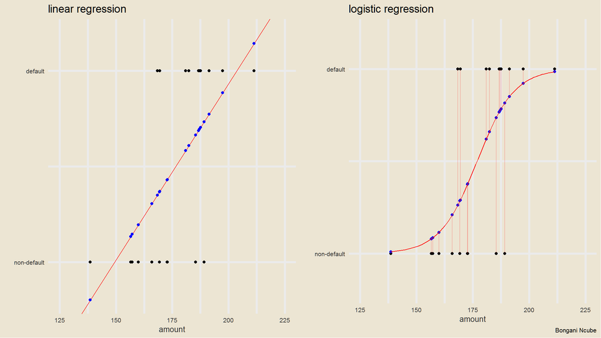

```r
loan_data <- loan_data %>%
  dplyr::mutate(Pred_lm = predict(lm1, loan_data),
                Pred_blm = predict(blr1, loan_data)) %>%
  dplyr::mutate(Prob_lm = plogis(predict(lm1, loan_data)),
                Prob_blm = plogis(predict(blr1, loan_data)),
                Pred_blm2 = ifelse(predict(blr1, loan_data, type = "response") >= .5, 1, 0))

p1 <- ggplot(loan_data, aes(x = interest, y =  loan_status)) +
  geom_point() +
  geom_abline(intercept = coef(lm1)[1], slope = coef(lm1)[2], color = "red", size = .5) +
  geom_point(aes(x = interest, y = Pred_lm), color = "blue") +
  tvthemes::theme_avatar()+
  coord_cartesian(ylim = c(-0.2, 1.2), xlim = c(125, 225)) +
  scale_y_continuous(breaks=seq(0, 1, 1), labels = c("non-default", "default")) +
  guides(fill = FALSE) +
  labs(title = "linear regression", x = "amount", y = "")


p2 <- ggplot(loan_data, aes(x = interest, y =  loan_status)) +
  geom_point() +
  geom_point(aes(x = interest, y = Prob_blm), color = "blue") +
  geom_smooth(method = "glm", method.args = list(family = "binomial"),
              se = FALSE, color = "red", size = .5) +
  geom_segment(aes(xend = interest, yend = Prob_blm), color = "red", alpha = .2) +
 tvthemes::theme_avatar()+
  coord_cartesian(ylim = c(-0.2, 1.2), xlim = c(125, 225)) +
  scale_y_continuous(breaks=seq(0, 1, 1), labels = c("non-default", "default")) +
  guides(fill = FALSE) +
  labs(title = "logistic regression", x = "amount", y = "",
       caption="Bongani Ncube")

ggpubr::ggarrange(p1, p2, ncol =2, nrow = 1)
```

## Deriving Logistic Regression

The structural form of the logistic regression model:

$logit( E[Y_i | X_i]) = logit(p_i) = ln(\frac{p_i}{1 - p_i}) = \beta_0 + \beta_1 X_{1i} + \epsilon$

$$p_i = f(\mathbf{x}_i ; \beta) =
\frac{exp(\mathbf{x_i'\beta})}{1 +
exp(\mathbf{x_i'\beta})}$$

Equivalently,

In this form, the model is specified such that **a function of the mean response is linear**. Hence, **Generalized Linear Models**

The likelihood function

$$L(p_i) = \prod_{i=1}^{n}
p_i^{Y_i}(1-p_i)^{1-Y_i}$$

where $p_i = \frac{\mathbf{x'_i \beta}}{1+\mathbf{x'_i \beta}}$ and $1-p_i = (1+ exp(\mathbf{x'_i \beta}))^{-1}$

Hence, our objective function is

$$Q(\beta) = log(L(\beta)) = \sum_{i=1}^n Y_i \mathbf{x'_i \beta} -
\sum_{i=1}^n log(1+ exp(\mathbf{x'_i \beta}))$$

## Multivariable logistic regression model

The structural form of the multivariable logistic regression model (this example uses two `X` variables):

$logit( E[Y_i | X_i]) = logit(p_i) = ln(\frac{p_i}{1 - p_i}) = \beta_0 + \beta_1 X_{1i} + + \beta_2 X_{2i} + \epsilon$

## Interpreting the coefficients

Our coefficients indicate the linear impact on the log odds of a positive decision. A negative coefficient decreases the log odds and a positive coefficient increases the log odds.

We can easily extend the manipulations from a few slides back to get a formula for the odds of an event in terms of the coefficents $\beta_0, \beta_1, ..., \beta_p$:

$$\begin{align*}
\frac{P(y = 1)}{P(y = 0)} &= e^{\beta_0 + \beta_1x_1 + ... +
\beta_px_p} \\
&= e^{\beta_0}(e^{\beta_1})^{x_1}...(e^{\beta_p})^{x_p}
\end{align*}$$

- $e^{\beta_0}$ is the odds of the event assuming zero from all input variables
- $e^{\beta_i}$ is the multiplier of the odds associated with a one unit increase in $x_i$ (for example, an extra point rating in physical attractiveness), assuming all else equal - because of the multiplicative effect, we call this the *odds ratio* for $x_i$.

### Categorical Explanatory Variable (2 Categories)

- *attrition_status* is modelled as a function of *Sex*.
- Reference group is *female*[^1].

```r
attrition_data<-readr::read_csv("data-attrition.csv") |>
  mutate(attrition_status= ifelse(attrition=="yes",1,0)) |>
  mutate(department=as.factor(department))

model1 <- glm(attrition_status ~ gender, family=binomial(link='logit'), data=attrition_data)
summary(model1)
```

```
#>
#> Call:
#> glm(formula = attrition_status ~ gender, family = binomial(link = "logit"),
#>     data = attrition_data)
#>
#> Coefficients:
#>             Estimate Std. Error z value Pr(>|z|)
#> (Intercept)  -1.7507     0.1161 -15.073   <2e-16 ***
#> gendermale    0.1656     0.1467   1.128    0.259
#> ---
#> Signif. codes:  0 '***' 0.001 '**' 0.01 '*' 0.05 '.' 0.1 ' ' 1
#>
#> (Dispersion parameter for binomial family taken to be 1)
#>
#>     Null deviance: 1298.6  on 1469  degrees of freedom
#> Residual deviance: 1297.3  on 1468  degrees of freedom
#> AIC: 1301.3
#>
#> Number of Fisher Scoring iterations: 4
```

### Categorical Explanatory Variable (More than 2 Categories)

- *attrition_status* is modeled as a function of *department*.
- The default reference group is *human resources*.

```r
model2 <- glm(attrition_status ~ department, family=binomial(link='logit'),
              data=na.omit(attrition_data))
summary(model2)
```

```
#>
#> Call:
#> glm(formula = attrition_status ~ department, family = binomial(link = "logit"),
#>     data = na.omit(attrition_data))
#>
#> Coefficients:
#>                                Estimate Std. Error z value Pr(>|z|)
#> (Intercept)                    -1.44692    0.32084  -4.510 6.49e-06 ***
#> departmentresearch_development -0.38175    0.33417  -1.142    0.253
#> departmentsales                 0.09941    0.34152   0.291    0.771
#> ---
#> Signif. codes:  0 '***' 0.001 '**' 0.01 '*' 0.05 '.' 0.1 ' ' 1
#>
#> (Dispersion parameter for binomial family taken to be 1)
#>
#>     Null deviance: 1298.6  on 1469  degrees of freedom
#> Residual deviance: 1288.1  on 1467  degrees of freedom
#> AIC: 1294.1
#>
#> Number of Fisher Scoring iterations: 4
```

- this is still nased on data **without** missing age rows.

```r
levels(attrition_data$department)
```

```
#> [1] "human_resources"      "research_development" "sales"
```

```
#> human_resources

#> research_development

#> sales
```

```r
attrition_data$departmentR <- relevel(attrition_data$department, ref=2)
levels(attrition_data$departmentR) # new col is not attached so must use data$
```

```
#> [1] "research_development" "human_resources"      "sales"
```

```
#> research_development

#> human_resources

#> sales
```

```r
model3 <- glm(attrition_status ~ departmentR, family=binomial(link='logit'),
              data=na.omit(attrition_data))
summary(model3)
```

```
#>
#> Call:
#> glm(formula = attrition_status ~ departmentR, family = binomial(link = "logit"),
#>     data = na.omit(attrition_data))
#>
#> Coefficients:
#>                            Estimate Std. Error z value Pr(>|z|)
#> (Intercept)                -1.82866    0.09342 -19.576  < 2e-16 ***
#> departmentRhuman_resources  0.38175    0.33417   1.142  0.25330
#> departmentRsales            0.48116    0.14974   3.213  0.00131 **
#> ---
#> Signif. codes:  0 '***' 0.001 '**' 0.01 '*' 0.05 '.' 0.1 ' ' 1
#>
#> (Dispersion parameter for binomial family taken to be 1)
#>
#>     Null deviance: 1298.6  on 1469  degrees of freedom
#> Residual deviance: 1288.1  on 1467  degrees of freedom
#> AIC: 1294.1
#>
#> Number of Fisher Scoring iterations: 4
```

.

### Continuous Explanatory Variable

- *attrition_status* is modelled as a function of *Age*.
- There is no reference group as such.
- **R “can deal with” missing data for a continuous variable** i.e.throws no error due to missing data in the continuous variable.

```r
model4 <- glm(attrition_status ~ age, family=binomial(link='logit'), data=attrition_data)
summary(model4)
```

```
#>
#> Call:
#> glm(formula = attrition_status ~ age, family = binomial(link = "logit"),
#>     data = attrition_data)
#>
#> Coefficients:
#>             Estimate Std. Error z value Pr(>|z|)
#> (Intercept)  0.20620    0.30599   0.674      0.5
#> age         -0.05225    0.00870  -6.006 1.91e-09 ***
#> ---
#> Signif. codes:  0 '***' 0.001 '**' 0.01 '*' 0.05 '.' 0.1 ' ' 1
#>
#> (Dispersion parameter for binomial family taken to be 1)
#>
#>     Null deviance: 1298.6  on 1469  degrees of freedom
#> Residual deviance: 1259.1  on 1468  degrees of freedom
#> AIC: 1263.1
#>
#> Number of Fisher Scoring iterations: 4
```

- **Intercept**: The log-odds of attrition when $Age = 0$ is 0.206199.
- **Age**:
  - For every unit increase in *Age* the log-odds of attrition decrease by -0.0522501 i.e. the chances of attrition decrease as employee`s age increases.
  - Given $p < 0.05$, we can **reject the null hypothesis** $b_1=0$ that one unit increase in age does not affect chances of attrition.
  - For every unit increase in *Age*, the odds of attrition are 0.9490914 times the odds of those with one *Age* unit less (i.e. -5.091 %).
[^1]: By default R assigns the reference group based on alphabetical order
[^2]: log-odds to odds-ratio: exp(log-odds)
[^3]: odds-ratio to %: (OR-1) * 100